# assignment1

2025-09-26

```r
library(readr)
library(lubridate)
library(dplyr)
library(ggplot2)
library(tidyr)
library(fastDummies)
```

## Exercise 1: Air Pollution Analysis

### A) Data Loading and Preprocessing

```r
data <- read.csv("air_polution.csv",
                 stringsAsFactors = FALSE,
                 fileEncoding = "UTF-8")

# Inspect
str(data)
```

```
## 'data.frame':    17566 obs. of  5 variables:
##  $ area     : chr  "Drammen" "Drammen" "Drammen" "Drammen" ...
##  $ station  : chr  "Backeparken" "Backeparken" "Backeparken" "Backeparken" ...
##  $ component: chr  "PM2.5" "PM2.5" "PM2.5" "PM2.5" ...
##  $ dateTime : chr  "2020-02-01T00:00:00+01:00" "2020-02-02T00:00:00+01:00" "2020-02-03T00:00:00+01:00" "2020-02-04T00:00:00+01:00" ...
##  $ value    : num  13.55 1.55 5.87 7.07 17.67 ...
```

```r
head(data)
```

```
##      area     station component                  dateTime     value
## 1 Drammen Backeparken     PM2.5 2020-02-01T00:00:00+01:00 13.554167
## 2 Drammen Backeparken     PM2.5 2020-02-02T00:00:00+01:00  1.550000
## 3 Drammen Backeparken     PM2.5 2020-02-03T00:00:00+01:00  5.866667
## 4 Drammen Backeparken     PM2.5 2020-02-04T00:00:00+01:00  7.070833
## 5 Drammen Backeparken     PM2.5 2020-02-05T00:00:00+01:00 17.670833
## 6 Drammen Backeparken     PM2.5 2020-02-06T00:00:00+01:00 10.016667
```

```r
summary(data)
```

```
##      area             station           component           dateTime
##  Length:17566       Length:17566       Length:17566       Length:17566
##  Class :character   Class :character   Class :character   Class :character
##  Mode  :character   Mode  :character   Mode  :character   Mode  :character
##
##
##
##      value
##  Min.   :  0.3913
##  1st Qu.:  4.8427
##  Median :  7.8252
##  Mean   : 10.4215
##  3rd Qu.: 12.7111
##  Max.   :135.1703
```

```r
data <- data %>%
  mutate(
    area = as.factor(area),              # convert area to factor
    station = as.factor(station),        # convert station to factor
    component = as.factor(component),    # convert component to factor
    dateTime = as.POSIXct(dateTime)       # convert dateTime to POSIXct (date-time)
  )
```

```r
# Inspect result
str(data)
```

```
## 'data.frame':    17566 obs. of  5 variables:
##  $ area     : Factor w/ 5 levels "Bergen","Drammen",..: 2 2 2 2 2 2 2 2 2 2 ...
##  $ station  : Factor w/ 5 levels "Backeparken",..: 1 1 1 1 1 1 1 1 1 1 ...
##  $ component: Factor w/ 2 levels "PM10","PM2.5": 2 2 2 2 2 2 2 2 2 2 ...
##  $ dateTime : POSIXct, format: "2020-02-01" "2020-02-02" ...
##  $ value    : num  13.55 1.55 5.87 7.07 17.67 ...
```

```r
summary(data)
```

```
##       area               station     component       dateTime
##  Bergen :4098   Backeparken  :4002   PM10 :9859   Min.   :2020-01-01 00:00:00
##  Drammen:4002   Klosterhaugen:4098   PM2.5:7707   1st Qu.:2021-06-06 00:00:00
##  Moss   :4006   Kransen      :4006                Median :2022-10-28 00:00:00
##  Oslo   :3469   Rambergan    :1991                Mean   :2022-11-01 06:05:45
##  Tromsø :1991   Skøyen       :3469                3rd Qu.:2024-03-08 00:00:00
##                                                   Max.   :2025-08-31 00:00:00
##      value
##  Min.   :  0.3913
##  1st Qu.:  4.8427
##  Median :  7.8252
##  Mean   : 10.4215
##  3rd Qu.: 12.7111
##  Max.   :135.1703
```

### B & C) Time Range Analysis

```r
time_ranges <- data %>%

  # make timeseries of each combination of area, station and component
  group_by(area, station, component) %>%
  summarise(
    # Add start_data and end_date columns
    start_date = min(dateTime),
    end_date   = max(dateTime),
    mean_value   = mean(value),
    sd_value     = sd(value),
    median_value = median(value),
    min_value    = min(value),
    max_value    = max(value),
    # For getting a clean summary table
    .groups = "drop"
  )

time_ranges
```

```
## # A tibble: 9 × 10
##   area    station   component start_date          end_date            mean_value
##   <fct>   <fct>     <fct>     <dttm>              <dttm>                   <dbl>
## 1 Bergen  Klosterh… PM10      2020-01-01 00:00:00 2025-08-31 00:00:00       9.42
## 2 Bergen  Klosterh… PM2.5     2020-01-01 00:00:00 2025-08-31 00:00:00       5.72
## 3 Drammen Backepar… PM10      2020-02-01 00:00:00 2025-08-24 00:00:00      14.3
## 4 Drammen Backepar… PM2.5     2020-02-01 00:00:00 2025-08-24 00:00:00       8.54
## 5 Moss    Kransen   PM10      2020-01-01 00:00:00 2025-08-31 00:00:00      14.5
## 6 Moss    Kransen   PM2.5     2020-01-01 00:00:00 2025-08-31 00:00:00       7.77
## 7 Oslo    Skøyen    PM10      2020-01-01 00:00:00 2025-08-31 00:00:00      15.1
## 8 Oslo    Skøyen    PM2.5     2020-06-10 00:00:00 2025-08-31 00:00:00       7.55
## 9 Tromsø  Rambergan PM10      2020-01-01 00:00:00 2025-08-31 00:00:00      11.0
## # ℹ 4 more variables: sd_value <dbl>, median_value <dbl>, min_value <dbl>,
## #   max_value <dbl>
```

```r
make_pm_plot <- function(data, pm_type) {
  data_filtered= data %>%
    filter(component == pm_type)

    ggplot(data_filtered ,aes(x = dateTime, y = value, color = area)) +
    geom_line() +
    labs(
      title = paste(pm_type, "over time"),
      x = "Date",
      y = bquote(.(pm_type) ~ "(" * mu * "g/m"^3 * ")"),
      color = "Area"
    )
}
```

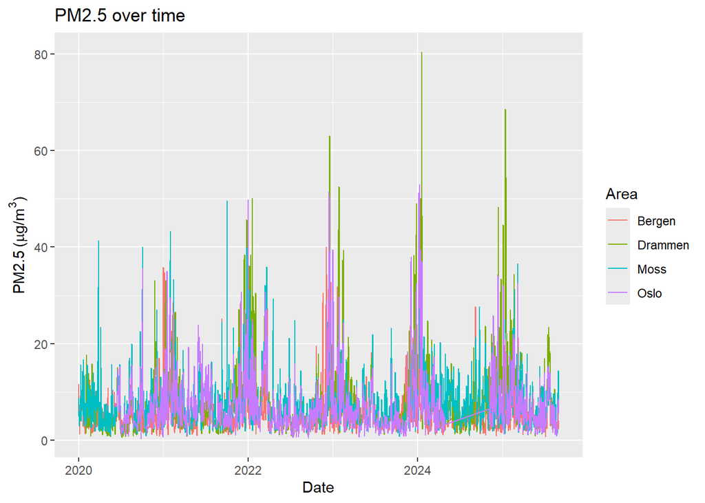

```r
# PM2.5 plot
pm25_plot <- make_pm_plot(data, "PM2.5")

# For popup window display
if (interactive()) {
  windows()  # Opens new window on Windows
  print(pm25_plot)
} else {
  pm25_plot  # For knitting
}
```

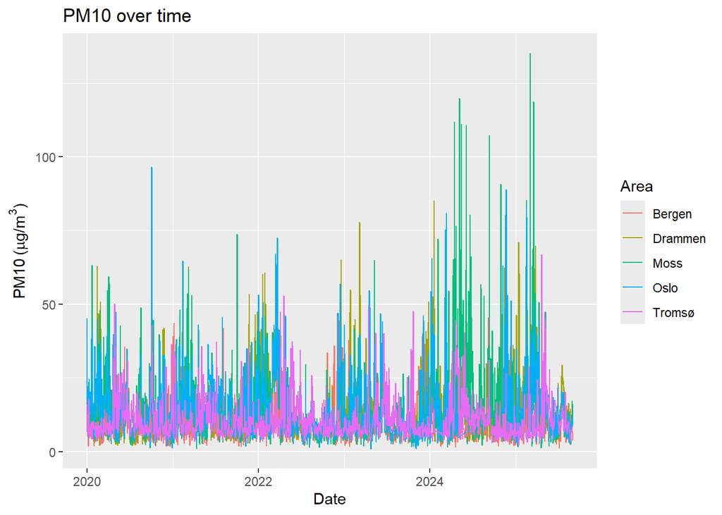

```r
# PM10 plot
pm10_plot <- make_pm_plot(data, "PM10")
pm10_plot
```

Comments on the plots: On the PM2.5 and PM10 plot, it looks like there is a gap or missing data on the Oslo “line” after x= 2024.

```r
sum(is.na(data))
```

```
## [1] 0
```

answer to d: Even to there are no Nan-values in the data set, the data set is still missing observations (rows). So we’re simply missing data on the visible gaps in the plots, the data is absent from the data set.

```r
data_aug2025 <- data %>%
  filter(year(dateTime) == 2025, month(dateTime) == 8)
```

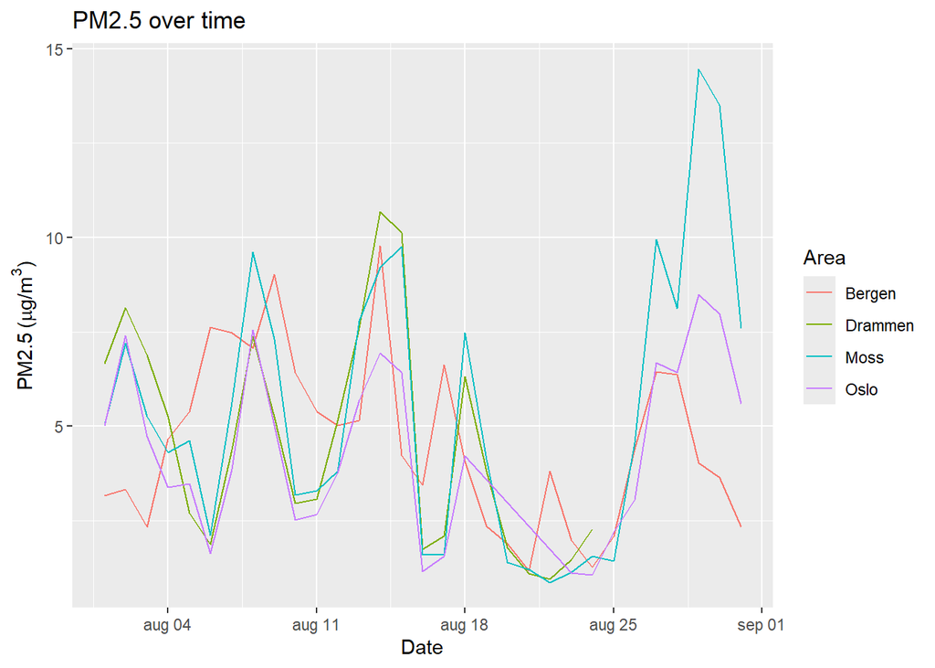

```r
# PM2.5 plot
pm25_plot <- make_pm_plot(data_aug2025, "PM2.5")
pm25_plot
```

Comments on plot: Drammen, Oslo, and Moss follow very similar trends in PM2.5 levels. Bergen shows more variation but still correlates somewhat with the others. Tromsø is not included in the PM2.5 plot because the dataset contains no PM2.5 measurements for Tromsø (only PM10).

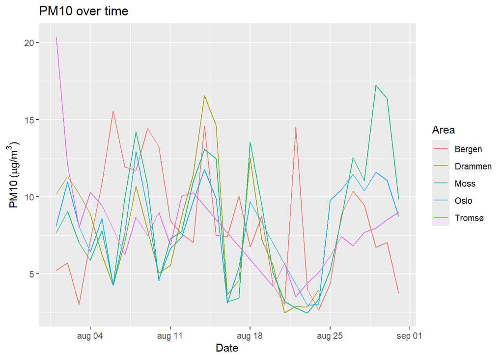

```r
# PM10 plot
pm10_plot <- make_pm_plot(data_aug2025, "PM10")
pm10_plot
```

Comments on plot: Drammen, Oslo, and Moss follow very similar trends in PM10 levels also. Tromsø and Bergen shows a bit more variation and has less correlation with the others

```r
make_pm_boxplot <- function(data, pm_type) {
  data_filtered= data %>%
    filter(component == pm_type)
  ggplot(data_filtered, aes(x = area, y = value, fill = area)) +
    geom_boxplot() +
    facet_wrap(~ component, scales = "free_y")
}
```

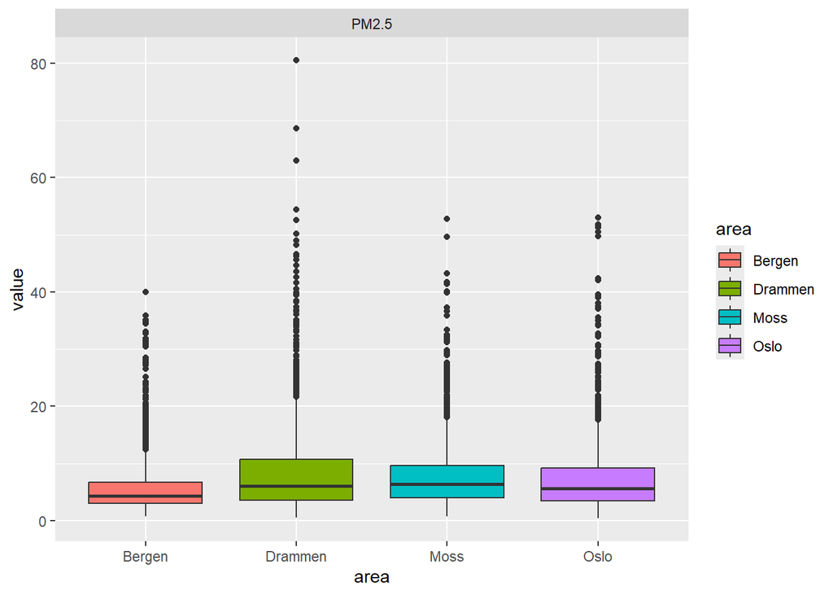

```r
# PM2.5 plot
pm25_boxplot <- make_pm_boxplot(data, "PM2.5")
pm25_boxplot
```

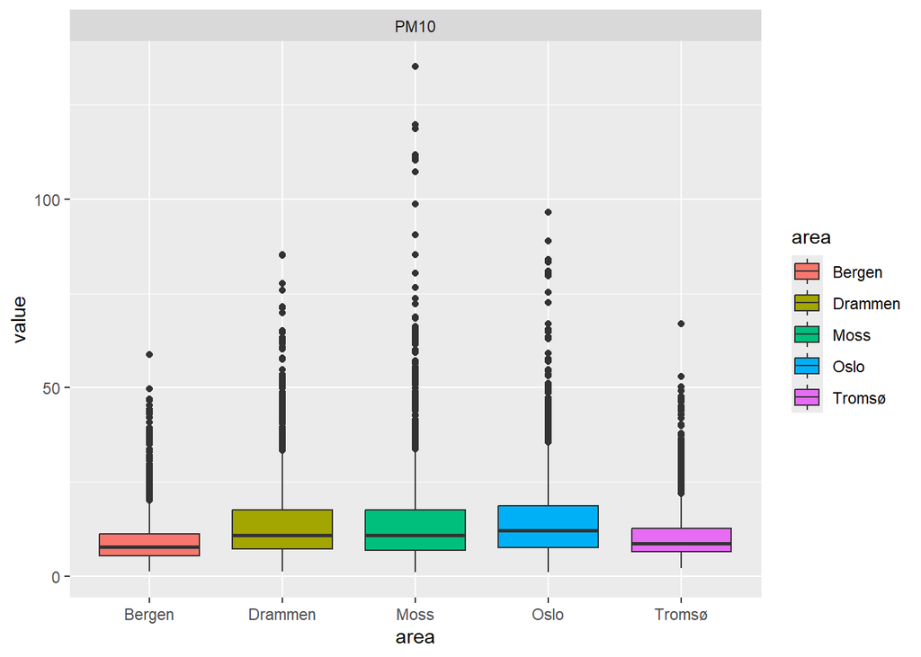

```r
# PM10 plot
pm10_boxplot <- make_pm_boxplot(data, "PM10")
pm10_boxplot
```

Excercise 2) a)

```r
library(readr)
temp_data <- read_csv2(
  "temperature_data.csv",
  col_types = cols(
    area     = col_character(),
    station  = col_character(),
    dateTime = col_date(format = "%d.%m.%Y"),
    avgTemp  = col_double()
  )
)
```

```
## ℹ Using "','" as decimal and "'.'" as grouping mark. Use `read_delim()` for more control.
```

```r
temp_data <- temp_data %>%
  mutate(
    area = as.factor(area),              # convert area to factor
    station = as.factor(station),        # convert station to factor
    dateTime = as.POSIXct(dateTime),       # convert dateTime to POSIXct (date-time)
    avgTemp = as.numeric(gsub(",", ".", avgTemp))
  )

# Inspect result
str(temp_data)
```

```
## tibble [1,751 × 4] (S3: tbl_df/tbl/data.frame)
##  $ area    : Factor w/ 5 levels "Bergen","Drammen",..: 3 3 3 3 3 3 3 3 3 3 ...
##  $ station : Factor w/ 5 levels "SN17150","SN18700",..: 1 1 1 1 1 1 1 1 1 1 ...
##  $ dateTime: POSIXct[1:1751], format: "2024-09-01" "2024-09-02" ...
##  $ avgTemp : num [1:1751] 14.1 12 16 17.8 20.3 19.2 18.8 19.1 17 14 ...
```

```r
summary(temp_data)
```

```
##       area        station       dateTime                      avgTemp
##  Bergen :366   SN17150:364   Min.   :2024-09-01 00:00:00   Min.   :-19.400
##  Drammen:349   SN18700:366   1st Qu.:2024-11-29 00:00:00   1st Qu.:  2.400
##  Moss   :364   SN26580:349   Median :2025-03-02 00:00:00   Median :  8.300
##  Oslo   :366   SN50540:366   Mean   :2025-03-02 06:58:35   Mean   :  7.898
##  Tromsø :306   SN91010:306   3rd Qu.:2025-06-03 12:00:00   3rd Qu.: 13.500
##                              Max.   :2025-09-01 00:00:00   Max.   : 25.600
```

```r
head(temp_data)
```

```
## # A tibble: 6 × 4
##   area  station dateTime            avgTemp
##   <fct> <fct>   <dttm>                <dbl>
## 1 Moss  SN17150 2024-09-01 00:00:00    14.1
## 2 Moss  SN17150 2024-09-02 00:00:00    12
## 3 Moss  SN17150 2024-09-03 00:00:00    16
## 4 Moss  SN17150 2024-09-04 00:00:00    17.8
## 5 Moss  SN17150 2024-09-05 00:00:00    20.3
## 6 Moss  SN17150 2024-09-06 00:00:00    19.2
```

```r
time_ranges <- temp_data %>%

  # make time-series of each combination of area, station and component
  group_by(area, station) %>%
  summarise(
    # Add start_data and end_date columns
    mean_value   = mean(avgTemp),
    sd_value     = sd(avgTemp),
    min_value    = min(avgTemp),
    max_value    = max(avgTemp),
    # For getting a clean summary table
    .groups = "drop"
  )

time_ranges
```

```
## # A tibble: 5 × 6
##   area    station mean_value sd_value min_value max_value
##   <fct>   <fct>        <dbl>    <dbl>     <dbl>     <dbl>
## 1 Bergen  SN50540       9.50     5.83      -4.8      24.3
## 2 Drammen SN26580       8.14     8.41     -12.2      24.8
## 3 Moss    SN17150       8.44     7.30     -12.6      24.3
## 4 Oslo    SN18700       8.42     7.69     -11        25.6
## 5 Tromsø  SN91010       4.42     8.00     -19.4      22.4
```

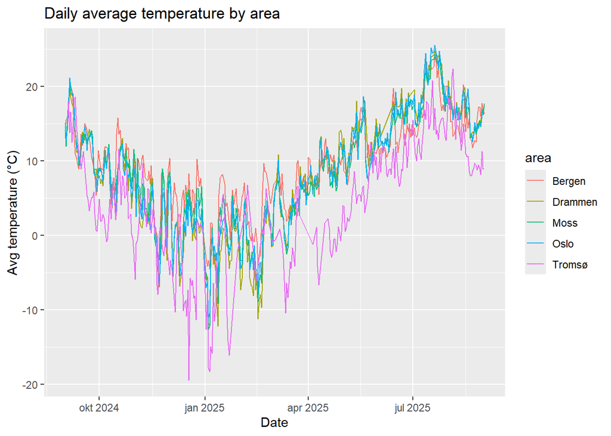

```r
ggplot(temp_data, aes(x = dateTime, y = avgTemp, color = area, group = area)) +
  geom_line() +
  labs(
    title = "Daily average temperature by area",
    x = "Date",
    y = "Avg temperature (\u00B0C)"
  )
```